# Risk Factor Analysis

## Outcome Variable

**Outcome Variable:** ever_sstunted

## Predictor Variables

**Intervention Variable:** mhtcm

**Adjustment Set:**

- arm
- W_mage
- meducyrs
- feducyrs
- hhwealth_quart
- delta_W_mage
- delta_meducyrs
- delta_feducyrs
- delta_hhwealth_quart

## Stratifying Variables

The analysis was stratified on these variable(s):

- agecat
- studyid
- country

## Data Summary

| agecat | studyid | country | mhtcm | ever_sstunted | n_cell | n |
| --- | --- | --- | --- | --- | --- | --- |
| 0-24 months | COHORTS | GUATEMALA | >=155 cm | 0 | 115 | 1292 |
| 0-24 months | COHORTS | GUATEMALA | >=155 cm | 1 | 51 | 1292 |
| 0-24 months | COHORTS | GUATEMALA | <151 cm | 0 | 412 | 1292 |
| 0-24 months | COHORTS | GUATEMALA | <151 cm | 1 | 433 | 1292 |
| 0-24 months | COHORTS | GUATEMALA | [151-155) cm | 0 | 160 | 1292 |
| 0-24 months | COHORTS | GUATEMALA | [151-155) cm | 1 | 121 | 1292 |
| 0-24 months | COHORTS | INDIA | >=155 cm | 0 | 540 | 1906 |
| 0-24 months | COHORTS | INDIA | >=155 cm | 1 | 31 | 1906 |
| 0-24 months | COHORTS | INDIA | <151 cm | 0 | 687 | 1906 |
| 0-24 months | COHORTS | INDIA | <151 cm | 1 | 137 | 1906 |
| 0-24 months | COHORTS | INDIA | [151-155) cm | 0 | 458 | 1906 |
| 0-24 months | COHORTS | INDIA | [151-155) cm | 1 | 53 | 1906 |
| 0-24 months | COHORTS | PHILIPPINES | >=155 cm | 0 | 490 | 3058 |
| 0-24 months | COHORTS | PHILIPPINES | >=155 cm | 1 | 142 | 3058 |
| 0-24 months | COHORTS | PHILIPPINES | <151 cm | 0 | 855 | 3058 |
| 0-24 months | COHORTS | PHILIPPINES | <151 cm | 1 | 694 | 3058 |
| 0-24 months | COHORTS | PHILIPPINES | [151-155) cm | 0 | 624 | 3058 |
| 0-24 months | COHORTS | PHILIPPINES | [151-155) cm | 1 | 253 | 3058 |
| 0-24 months | Guatemala BSC | GUATEMALA | >=155 cm | 0 | 32 | 235 |
| 0-24 months | Guatemala BSC | GUATEMALA | >=155 cm | 1 | 4 | 235 |
| 0-24 months | Guatemala BSC | GUATEMALA | <151 cm | 0 | 108 | 235 |
| 0-24 months | Guatemala BSC | GUATEMALA | <151 cm | 1 | 35 | 235 |
| 0-24 months | Guatemala BSC | GUATEMALA | [151-155) cm | 0 | 47 | 235 |
| 0-24 months | Guatemala BSC | GUATEMALA | [151-155) cm | 1 | 9 | 235 |
| 0-24 months | iLiNS-Zinc | BURKINA FASO | >=155 cm | 0 | 2628 | 3216 |
| 0-24 months | iLiNS-Zinc | BURKINA FASO | >=155 cm | 1 | 271 | 3216 |
| 0-24 months | iLiNS-Zinc | BURKINA FASO | <151 cm | 0 | 69 | 3216 |
| 0-24 months | iLiNS-Zinc | BURKINA FASO | <151 cm | 1 | 22 | 3216 |
| 0-24 months | iLiNS-Zinc | BURKINA FASO | [151-155) cm | 0 | 181 | 3216 |
| 0-24 months | iLiNS-Zinc | BURKINA FASO | [151-155) cm | 1 | 45 | 3216 |

[output cut: 240 more lines]

The following strata were considered:

- agecat: 0-24 months, studyid: COHORTS, country: GUATEMALA
- agecat: 0-24 months, studyid: COHORTS, country: INDIA
- agecat: 0-24 months, studyid: COHORTS, country: PHILIPPINES
- agecat: 0-24 months, studyid: Guatemala BSC, country: GUATEMALA
- agecat: 0-24 months, studyid: iLiNS-Zinc, country: BURKINA FASO
- agecat: 0-24 months, studyid: JiVitA-3, country: BANGLADESH
- agecat: 0-24 months, studyid: Keneba, country: GAMBIA
- agecat: 0-24 months, studyid: LCNI-5, country: MALAWI
- agecat: 0-24 months, studyid: MAL-ED, country: BANGLADESH
- agecat: 0-24 months, studyid: MAL-ED, country: BRAZIL
- agecat: 0-24 months, studyid: MAL-ED, country: INDIA
- agecat: 0-24 months, studyid: MAL-ED, country: NEPAL
- agecat: 0-24 months, studyid: MAL-ED, country: PERU
- agecat: 0-24 months, studyid: MAL-ED, country: SOUTH AFRICA
- agecat: 0-24 months, studyid: MAL-ED, country: TANZANIA, UNITED REPUBLIC OF
- agecat: 0-24 months, studyid: NIH-Birth, country: BANGLADESH
- agecat: 0-24 months, studyid: NIH-Crypto, country: BANGLADESH
- agecat: 0-24 months, studyid: PROBIT, country: BELARUS
- agecat: 0-24 months, studyid: PROVIDE, country: BANGLADESH
- agecat: 0-24 months, studyid: SAS-CompFeed, country: INDIA
- agecat: 0-24 months, studyid: SAS-FoodSuppl, country: INDIA
- agecat: 0-24 months, studyid: TanzaniaChild2, country: TANZANIA, UNITED REPUBLIC OF
- agecat: 0-24 months, studyid: ZVITAMBO, country: ZIMBABWE
- agecat: 0-6 months, studyid: COHORTS, country: GUATEMALA
- agecat: 0-6 months, studyid: COHORTS, country: INDIA
- agecat: 0-6 months, studyid: COHORTS, country: PHILIPPINES
- agecat: 0-6 months, studyid: Guatemala BSC, country: GUATEMALA
- agecat: 0-6 months, studyid: JiVitA-3, country: BANGLADESH
- agecat: 0-6 months, studyid: Keneba, country: GAMBIA
- agecat: 0-6 months, studyid: LCNI-5, country: MALAWI
- agecat: 0-6 months, studyid: MAL-ED, country: BANGLADESH
- agecat: 0-6 months, studyid: MAL-ED, country: BRAZIL
- agecat: 0-6 months, studyid: MAL-ED, country: INDIA
- agecat: 0-6 months, studyid: MAL-ED, country: NEPAL
- agecat: 0-6 months, studyid: MAL-ED, country: PERU
- agecat: 0-6 months, studyid: MAL-ED, country: SOUTH AFRICA
- agecat: 0-6 months, studyid: MAL-ED, country: TANZANIA, UNITED REPUBLIC OF
- agecat: 0-6 months, studyid: NIH-Birth, country: BANGLADESH
- agecat: 0-6 months, studyid: NIH-Crypto, country: BANGLADESH
- agecat: 0-6 months, studyid: PROBIT, country: BELARUS
- agecat: 0-6 months, studyid: PROVIDE, country: BANGLADESH
- agecat: 0-6 months, studyid: SAS-CompFeed, country: INDIA
- agecat: 0-6 months, studyid: SAS-FoodSuppl, country: INDIA
- agecat: 0-6 months, studyid: TanzaniaChild2, country: TANZANIA, UNITED REPUBLIC OF
- agecat: 0-6 months, studyid: ZVITAMBO, country: ZIMBABWE

### Dropped Strata

Some strata were dropped due to rare outcomes:

- agecat: 0-24 months, studyid: Guatemala BSC, country: GUATEMALA
- agecat: 0-24 months, studyid: MAL-ED, country: BANGLADESH
- agecat: 0-24 months, studyid: MAL-ED, country: NEPAL
- agecat: 0-6 months, studyid: Guatemala BSC, country: GUATEMALA
- agecat: 0-6 months, studyid: MAL-ED, country: BANGLADESH
- agecat: 0-6 months, studyid: MAL-ED, country: BRAZIL
- agecat: 0-6 months, studyid: MAL-ED, country: INDIA
- agecat: 0-6 months, studyid: MAL-ED, country: NEPAL
- agecat: 0-6 months, studyid: MAL-ED, country: SOUTH AFRICA
- agecat: 0-6 months, studyid: PROVIDE, country: BANGLADESH
- agecat: 0-6 months, studyid: SAS-FoodSuppl, country: INDIA

## Methods Detail

We’re interested in the causal parameters $E[Y_a]$ for all values of $a \in \mathcal{A}$. These parameters represent the mean outcome if, possibly contrary to fact, we intervened to set all units to have $A=a$. Under the randomization and positivity assumptions, these are identified by the statistical parameters $\psi_a=E_W[E_{Y|A,W}(Y|A=a,W)]$. In addition, we’re interested in the mean of $Y$, $E[Y]$ under no intervention (the observed mean). We will estimate these parameters by using SuperLearner to fit the relevant likelihood factors – $E_{Y|A,W}(Y|A=a,W)$ and $p(A=a|W)$, and then updating our likelihood fit using a joint TMLE.

For unadjusted analyses ($W=\{\}$), initial likelihoods were estimated using Lrnr_glm to estimate the simple $E(Y|A)$ and Lrnr_mean to estimate $p(A)$. For adjusted analyses, a small library containing Lrnr_glmnet, Lrnr_xgboost, and Lrnr_mean was used.

Having estimated these parameters, we will then use the delta method to estimate relative risks and attributable risks relative to a prespecified baseline level of $A$.

# Results Detail

## Results Plots

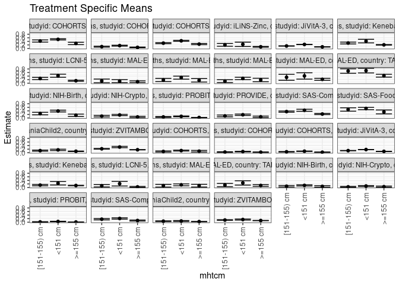

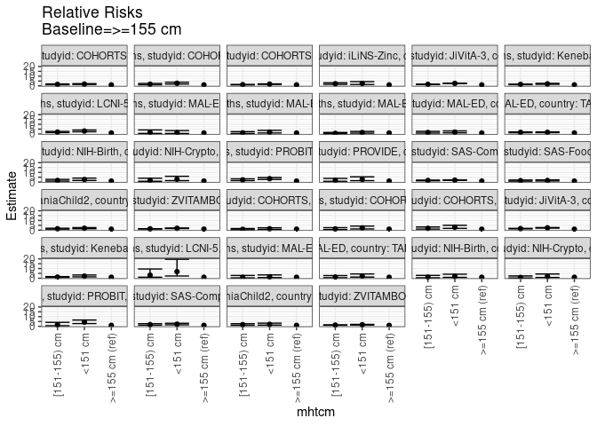

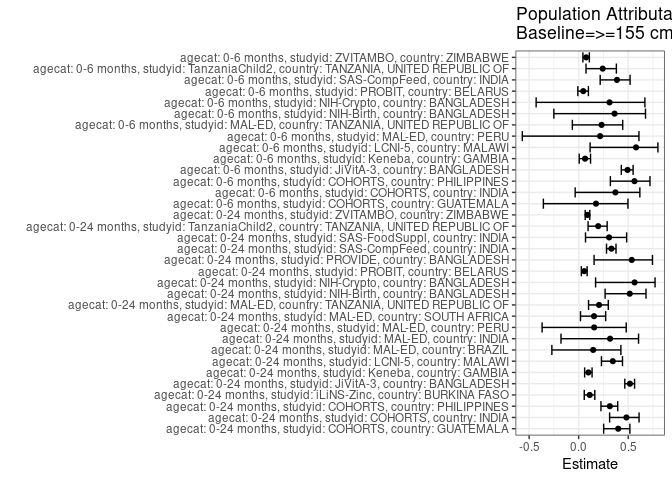

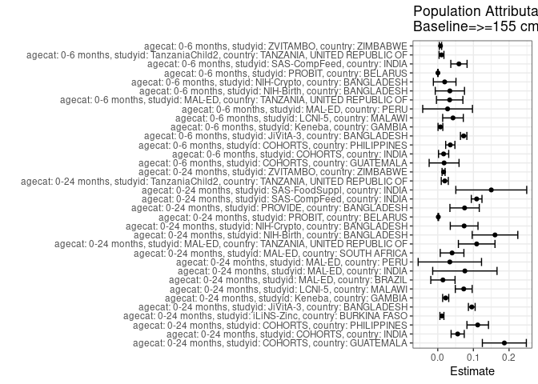

## Results Table

### Parameter: TSM

| agecat | studyid | country | intervention_level | baseline_level | estimate | ci_lower | ci_upper |
| --- | --- | --- | --- | --- | --- | --- | --- |
| 0-24 months | COHORTS | GUATEMALA | >=155 cm | NA | 0.2814497 | 0.2167063 | 0.3461931 |
| 0-24 months | COHORTS | GUATEMALA | <151 cm | NA | 0.5105376 | 0.4763855 | 0.5446897 |
| 0-24 months | COHORTS | GUATEMALA | [151-155) cm | NA | 0.4184786 | 0.3574456 | 0.4795116 |
| 0-24 months | COHORTS | INDIA | >=155 cm | NA | 0.0600707 | 0.0415784 | 0.0785631 |
| 0-24 months | COHORTS | INDIA | <151 cm | NA | 0.1593240 | 0.1340263 | 0.1846217 |
| 0-24 months | COHORTS | INDIA | [151-155) cm | NA | 0.1024427 | 0.0760579 | 0.1288275 |
| 0-24 months | COHORTS | PHILIPPINES | >=155 cm | NA | 0.2440456 | 0.2112403 | 0.2768510 |
| 0-24 months | COHORTS | PHILIPPINES | <151 cm | NA | 0.4297377 | 0.4053650 | 0.4541103 |
| 0-24 months | COHORTS | PHILIPPINES | [151-155) cm | NA | 0.2986551 | 0.2686754 | 0.3286347 |
| 0-24 months | iLiNS-Zinc | BURKINA FASO | >=155 cm | NA | 0.0934164 | 0.0741479 | 0.1126849 |
| 0-24 months | iLiNS-Zinc | BURKINA FASO | <151 cm | NA | 0.2319365 | 0.1099152 | 0.3539579 |
| 0-24 months | iLiNS-Zinc | BURKINA FASO | [151-155) cm | NA | 0.2022704 | 0.1245579 | 0.2799829 |
| 0-24 months | JiVitA-3 | BANGLADESH | >=155 cm | NA | 0.0890058 | 0.0794370 | 0.0985746 |
| 0-24 months | JiVitA-3 | BANGLADESH | <151 cm | NA | 0.2258184 | 0.2180696 | 0.2335671 |
| 0-24 months | JiVitA-3 | BANGLADESH | [151-155) cm | NA | 0.1384503 | 0.1290715 | 0.1478291 |
| 0-24 months | Keneba | GAMBIA | >=155 cm | NA | 0.2036586 | 0.1860646 | 0.2212525 |
| 0-24 months | Keneba | GAMBIA | <151 cm | NA | 0.4131565 | 0.3117684 | 0.5145446 |
| 0-24 months | Keneba | GAMBIA | [151-155) cm | NA | 0.3048690 | 0.2545503 | 0.3551877 |
| 0-24 months | LCNI-5 | MALAWI | >=155 cm | NA | 0.1385844 | 0.1087894 | 0.1683793 |
| 0-24 months | LCNI-5 | MALAWI | <151 cm | NA | 0.4196094 | 0.3332662 | 0.5059527 |
| 0-24 months | LCNI-5 | MALAWI | [151-155) cm | NA | 0.2643074 | 0.2011927 | 0.3274221 |
| 0-24 months | MAL-ED | BRAZIL | >=155 cm | NA | 0.0846154 | 0.0366660 | 0.1325648 |
| 0-24 months | MAL-ED | BRAZIL | <151 cm | NA | 0.1132075 | 0.0277128 | 0.1987022 |
| 0-24 months | MAL-ED | BRAZIL | [151-155) cm | NA | 0.1282051 | 0.0230438 | 0.2333664 |
| 0-24 months | MAL-ED | INDIA | >=155 cm | NA | 0.1636364 | 0.0656640 | 0.2616087 |
| 0-24 months | MAL-ED | INDIA | <151 cm | NA | 0.3130435 | 0.2281127 | 0.3979743 |
| 0-24 months | MAL-ED | INDIA | [151-155) cm | NA | 0.1805556 | 0.0915235 | 0.2695876 |
| 0-24 months | MAL-ED | PERU | >=155 cm | NA | 0.1833333 | 0.0852567 | 0.2814100 |
| 0-24 months | MAL-ED | PERU | <151 cm | NA | 0.2662722 | 0.1995170 | 0.3330274 |
| 0-24 months | MAL-ED | PERU | [151-155) cm | NA | 0.1147541 | 0.0346326 | 0.1948756 |

[output cut: 72 more lines]

### Parameter: E(Y)

| agecat | studyid | country | intervention_level | baseline_level | estimate | ci_lower | ci_upper |
| --- | --- | --- | --- | --- | --- | --- | --- |
| 0-24 months | COHORTS | GUATEMALA | NA | NA | 0.4682663 | 0.4410469 | 0.4954857 |
| 0-24 months | COHORTS | INDIA | NA | NA | 0.1159496 | 0.1015724 | 0.1303268 |
| 0-24 months | COHORTS | PHILIPPINES | NA | NA | 0.3561151 | 0.3391405 | 0.3730897 |
| 0-24 months | iLiNS-Zinc | BURKINA FASO | NA | NA | 0.1050995 | 0.0855497 | 0.1246493 |
| 0-24 months | JiVitA-3 | BANGLADESH | NA | NA | 0.1844241 | 0.1788262 | 0.1900221 |
| 0-24 months | Keneba | GAMBIA | NA | NA | 0.2259259 | 0.2092953 | 0.2425566 |
| 0-24 months | LCNI-5 | MALAWI | NA | NA | 0.2114695 | 0.1837888 | 0.2391503 |
| 0-24 months | MAL-ED | BRAZIL | NA | NA | 0.0990991 | 0.0597055 | 0.1384927 |
| 0-24 months | MAL-ED | INDIA | NA | NA | 0.2396694 | 0.1857746 | 0.2935643 |
| 0-24 months | MAL-ED | PERU | NA | NA | 0.2172414 | 0.1696986 | 0.2647841 |
| 0-24 months | MAL-ED | SOUTH AFRICA | NA | NA | 0.2592593 | 0.2068905 | 0.3116280 |
| 0-24 months | MAL-ED | TANZANIA, UNITED REPUBLIC OF | NA | NA | 0.5312500 | 0.4700011 | 0.5924989 |
| 0-24 months | NIH-Birth | BANGLADESH | NA | NA | 0.3116057 | 0.2753823 | 0.3478292 |
| 0-24 months | NIH-Crypto | BANGLADESH | NA | NA | 0.1311258 | 0.1070332 | 0.1552185 |
| 0-24 months | PROBIT | BELARUS | NA | NA | 0.0270861 | 0.0199367 | 0.0342354 |
| 0-24 months | PROVIDE | BANGLADESH | NA | NA | 0.1405082 | 0.1141551 | 0.1668613 |
| 0-24 months | SAS-CompFeed | INDIA | NA | NA | 0.3297797 | 0.2987556 | 0.3608038 |
| 0-24 months | SAS-FoodSuppl | INDIA | NA | NA | 0.4889976 | 0.4404930 | 0.5375021 |
| 0-24 months | TanzaniaChild2 | TANZANIA, UNITED REPUBLIC OF | NA | NA | 0.1000424 | 0.0879314 | 0.1121534 |
| 0-24 months | ZVITAMBO | ZIMBABWE | NA | NA | 0.1827040 | 0.1750732 | 0.1903348 |
| 0-6 months | COHORTS | GUATEMALA | NA | NA | 0.1018692 | 0.0837370 | 0.1200014 |
| 0-6 months | COHORTS | INDIA | NA | NA | 0.0443376 | 0.0350104 | 0.0536648 |
| 0-6 months | COHORTS | PHILIPPINES | NA | NA | 0.0624591 | 0.0538810 | 0.0710373 |
| 0-6 months | JiVitA-3 | BANGLADESH | NA | NA | 0.1472633 | 0.1422106 | 0.1523160 |
| 0-6 months | Keneba | GAMBIA | NA | NA | 0.1163114 | 0.1027818 | 0.1298410 |
| 0-6 months | LCNI-5 | MALAWI | NA | NA | 0.0738007 | 0.0426155 | 0.1049860 |
| 0-6 months | MAL-ED | PERU | NA | NA | 0.1275862 | 0.0891215 | 0.1660509 |
| 0-6 months | MAL-ED | TANZANIA, UNITED REPUBLIC OF | NA | NA | 0.1445312 | 0.1013733 | 0.1876892 |
| 0-6 months | NIH-Birth | BANGLADESH | NA | NA | 0.0937997 | 0.0709973 | 0.1166021 |
| 0-6 months | NIH-Crypto | BANGLADESH | NA | NA | 0.0622517 | 0.0450059 | 0.0794974 |
| 0-6 months | PROBIT | BELARUS | NA | NA | 0.0096840 | 0.0063336 | 0.0130344 |
| 0-6 months | SAS-CompFeed | INDIA | NA | NA | 0.1538462 | 0.1345929 | 0.1730994 |
| 0-6 months | TanzaniaChild2 | TANZANIA, UNITED REPUBLIC OF | NA | NA | 0.0432387 | 0.0350292 | 0.0514481 |
| 0-6 months | ZVITAMBO | ZIMBABWE | NA | NA | 0.1005995 | 0.0946563 | 0.1065428 |

### Parameter: RR

| agecat | studyid | country | intervention_level | baseline_level | estimate | ci_lower | ci_upper |
| --- | --- | --- | --- | --- | --- | --- | --- |
| 0-24 months | COHORTS | GUATEMALA | >=155 cm | >=155 cm | 1.0000000 | 1.0000000 | 1.000000 |
| 0-24 months | COHORTS | GUATEMALA | <151 cm | >=155 cm | 1.8139566 | 1.4282792 | 2.303778 |
| 0-24 months | COHORTS | GUATEMALA | [151-155) cm | >=155 cm | 1.4868680 | 1.1325713 | 1.951998 |
| 0-24 months | COHORTS | INDIA | >=155 cm | >=155 cm | 1.0000000 | 1.0000000 | 1.000000 |
| 0-24 months | COHORTS | INDIA | <151 cm | >=155 cm | 2.6522734 | 1.8786442 | 3.744484 |
| 0-24 months | COHORTS | INDIA | [151-155) cm | >=155 cm | 1.7053673 | 1.1437708 | 2.542710 |
| 0-24 months | COHORTS | PHILIPPINES | >=155 cm | >=155 cm | 1.0000000 | 1.0000000 | 1.000000 |
| 0-24 months | COHORTS | PHILIPPINES | <151 cm | >=155 cm | 1.7608909 | 1.5230525 | 2.035870 |
| 0-24 months | COHORTS | PHILIPPINES | [151-155) cm | >=155 cm | 1.2237674 | 1.0356461 | 1.446060 |
| 0-24 months | iLiNS-Zinc | BURKINA FASO | >=155 cm | >=155 cm | 1.0000000 | 1.0000000 | 1.000000 |
| 0-24 months | iLiNS-Zinc | BURKINA FASO | <151 cm | >=155 cm | 2.4828251 | 1.4144083 | 4.358303 |
| 0-24 months | iLiNS-Zinc | BURKINA FASO | [151-155) cm | >=155 cm | 2.1652567 | 1.4874270 | 3.151978 |
| 0-24 months | JiVitA-3 | BANGLADESH | >=155 cm | >=155 cm | 1.0000000 | 1.0000000 | 1.000000 |
| 0-24 months | JiVitA-3 | BANGLADESH | <151 cm | >=155 cm | 2.5371205 | 2.2735020 | 2.831306 |
| 0-24 months | JiVitA-3 | BANGLADESH | [151-155) cm | >=155 cm | 1.5555205 | 1.3691623 | 1.767244 |
| 0-24 months | Keneba | GAMBIA | >=155 cm | >=155 cm | 1.0000000 | 1.0000000 | 1.000000 |
| 0-24 months | Keneba | GAMBIA | <151 cm | >=155 cm | 2.0286725 | 1.5639879 | 2.631422 |
| 0-24 months | Keneba | GAMBIA | [151-155) cm | >=155 cm | 1.4969613 | 1.2428720 | 1.802996 |
| 0-24 months | LCNI-5 | MALAWI | >=155 cm | >=155 cm | 1.0000000 | 1.0000000 | 1.000000 |
| 0-24 months | LCNI-5 | MALAWI | <151 cm | >=155 cm | 3.0278269 | 2.2499700 | 4.074604 |
| 0-24 months | LCNI-5 | MALAWI | [151-155) cm | >=155 cm | 1.9071954 | 1.3836262 | 2.628885 |
| 0-24 months | MAL-ED | BRAZIL | >=155 cm | >=155 cm | 1.0000000 | 1.0000000 | 1.000000 |
| 0-24 months | MAL-ED | BRAZIL | <151 cm | >=155 cm | 1.3379074 | 0.5204504 | 3.439321 |
| 0-24 months | MAL-ED | BRAZIL | [151-155) cm | >=155 cm | 1.5151515 | 0.5590860 | 4.106137 |
| 0-24 months | MAL-ED | INDIA | >=155 cm | >=155 cm | 1.0000000 | 1.0000000 | 1.000000 |
| 0-24 months | MAL-ED | INDIA | <151 cm | >=155 cm | 1.9130435 | 0.9914102 | 3.691444 |
| 0-24 months | MAL-ED | INDIA | [151-155) cm | >=155 cm | 1.1033951 | 0.5080144 | 2.396548 |
| 0-24 months | MAL-ED | PERU | >=155 cm | >=155 cm | 1.0000000 | 1.0000000 | 1.000000 |
| 0-24 months | MAL-ED | PERU | <151 cm | >=155 cm | 1.4523938 | 0.8044622 | 2.622184 |
| 0-24 months | MAL-ED | PERU | [151-155) cm | >=155 cm | 0.6259314 | 0.2597331 | 1.508434 |

[output cut: 72 more lines]

### Parameter: PAR

| agecat | studyid | country | intervention_level | baseline_level | estimate | ci_lower | ci_upper |
| --- | --- | --- | --- | --- | --- | --- | --- |
| 0-24 months | COHORTS | GUATEMALA | >=155 cm | NA | 0.1868165 | 0.1251248 | 0.2485083 |
| 0-24 months | COHORTS | INDIA | >=155 cm | NA | 0.0558789 | 0.0374461 | 0.0743117 |
| 0-24 months | COHORTS | PHILIPPINES | >=155 cm | NA | 0.1120695 | 0.0818733 | 0.1422657 |
| 0-24 months | iLiNS-Zinc | BURKINA FASO | >=155 cm | NA | 0.0116831 | 0.0060930 | 0.0172732 |
| 0-24 months | JiVitA-3 | BANGLADESH | >=155 cm | NA | 0.0954183 | 0.0859817 | 0.1048550 |
| 0-24 months | Keneba | GAMBIA | >=155 cm | NA | 0.0222674 | 0.0137234 | 0.0308113 |
| 0-24 months | LCNI-5 | MALAWI | >=155 cm | NA | 0.0728852 | 0.0492100 | 0.0965603 |
| 0-24 months | MAL-ED | BRAZIL | >=155 cm | NA | 0.0144837 | -0.0195502 | 0.0485176 |
| 0-24 months | MAL-ED | INDIA | >=155 cm | NA | 0.0760331 | -0.0141902 | 0.1662563 |
| 0-24 months | MAL-ED | PERU | >=155 cm | NA | 0.0339080 | -0.0549686 | 0.1227847 |
| 0-24 months | MAL-ED | SOUTH AFRICA | >=155 cm | NA | 0.0401770 | 0.0070134 | 0.0733406 |
| 0-24 months | MAL-ED | TANZANIA, UNITED REPUBLIC OF | >=155 cm | NA | 0.1092250 | 0.0578882 | 0.1605619 |
| 0-24 months | NIH-Birth | BANGLADESH | >=155 cm | NA | 0.1605824 | 0.0966135 | 0.2245512 |
| 0-24 months | NIH-Crypto | BANGLADESH | >=155 cm | NA | 0.0739830 | 0.0351014 | 0.1128645 |
| 0-24 months | PROBIT | BELARUS | >=155 cm | NA | 0.0015326 | 0.0006408 | 0.0024243 |
| 0-24 months | PROVIDE | BANGLADESH | >=155 cm | NA | 0.0752908 | 0.0341461 | 0.1164356 |
| 0-24 months | SAS-CompFeed | INDIA | >=155 cm | NA | 0.1090627 | 0.0940860 | 0.1240395 |
| 0-24 months | SAS-FoodSuppl | INDIA | >=155 cm | NA | 0.1501256 | 0.0506884 | 0.2495629 |
| 0-24 months | TanzaniaChild2 | TANZANIA, UNITED REPUBLIC OF | >=155 cm | NA | 0.0197087 | 0.0098454 | 0.0295720 |
| 0-24 months | ZVITAMBO | ZIMBABWE | >=155 cm | NA | 0.0163249 | 0.0120648 | 0.0205851 |
| 0-6 months | COHORTS | GUATEMALA | >=155 cm | NA | 0.0177821 | -0.0241383 | 0.0597026 |
| 0-6 months | COHORTS | INDIA | >=155 cm | NA | 0.0164392 | 0.0021363 | 0.0307421 |
| 0-6 months | COHORTS | PHILIPPINES | >=155 cm | NA | 0.0351897 | 0.0222446 | 0.0481349 |
| 0-6 months | JiVitA-3 | BANGLADESH | >=155 cm | NA | 0.0726527 | 0.0636601 | 0.0816454 |
| 0-6 months | Keneba | GAMBIA | >=155 cm | NA | 0.0074833 | 0.0007848 | 0.0141817 |
| 0-6 months | LCNI-5 | MALAWI | >=155 cm | NA | 0.0427448 | 0.0138156 | 0.0716740 |
| 0-6 months | MAL-ED | PERU | >=155 cm | NA | 0.0275862 | -0.0421924 | 0.0973648 |
| 0-6 months | MAL-ED | TANZANIA, UNITED REPUBLIC OF | >=155 cm | NA | 0.0334201 | -0.0036795 | 0.0705198 |
| 0-6 months | NIH-Birth | BANGLADESH | >=155 cm | NA | 0.0339706 | -0.0070364 | 0.0749777 |
| 0-6 months | NIH-Crypto | BANGLADESH | >=155 cm | NA | 0.0193945 | -0.0123307 | 0.0511197 |
| 0-6 months | PROBIT | BELARUS | >=155 cm | NA | 0.0004493 | -0.0000833 | 0.0009818 |
| 0-6 months | SAS-CompFeed | INDIA | >=155 cm | NA | 0.0594277 | 0.0366338 | 0.0822215 |
| 0-6 months | TanzaniaChild2 | TANZANIA, UNITED REPUBLIC OF | >=155 cm | NA | 0.0104933 | 0.0036335 | 0.0173531 |
| 0-6 months | ZVITAMBO | ZIMBABWE | >=155 cm | NA | 0.0076235 | 0.0043251 | 0.0109218 |

### Parameter: PAF

| agecat | studyid | country | intervention_level | baseline_level | estimate | ci_lower | ci_upper |
| --- | --- | --- | --- | --- | --- | --- | --- |
| 0-24 months | COHORTS | GUATEMALA | >=155 cm | NA | 0.3989536 | 0.2521664 | 0.5169290 |
| 0-24 months | COHORTS | INDIA | >=155 cm | NA | 0.4819238 | 0.3123848 | 0.6096612 |
| 0-24 months | COHORTS | PHILIPPINES | >=155 cm | NA | 0.3147002 | 0.2249870 | 0.3940285 |
| 0-24 months | iLiNS-Zinc | BURKINA FASO | >=155 cm | NA | 0.1111625 | 0.0563181 | 0.1628195 |
| 0-24 months | JiVitA-3 | BANGLADESH | >=155 cm | NA | 0.5173854 | 0.4655262 | 0.5642128 |
| 0-24 months | Keneba | GAMBIA | >=155 cm | NA | 0.0985605 | 0.0602799 | 0.1352817 |
| 0-24 months | LCNI-5 | MALAWI | >=155 cm | NA | 0.3446604 | 0.2298841 | 0.4423307 |
| 0-24 months | MAL-ED | BRAZIL | >=155 cm | NA | 0.1461538 | -0.2706298 | 0.4262268 |
| 0-24 months | MAL-ED | INDIA | >=155 cm | NA | 0.3172414 | -0.1783116 | 0.6043837 |
| 0-24 months | MAL-ED | PERU | >=155 cm | NA | 0.1560847 | -0.3691355 | 0.4798228 |
| 0-24 months | MAL-ED | SOUTH AFRICA | >=155 cm | NA | 0.1549684 | 0.0185162 | 0.2724502 |
| 0-24 months | MAL-ED | TANZANIA, UNITED REPUBLIC OF | >=155 cm | NA | 0.2056001 | 0.0997822 | 0.2989793 |
| 0-24 months | NIH-Birth | BANGLADESH | >=155 cm | NA | 0.5153383 | 0.2668536 | 0.6796043 |
| 0-24 months | NIH-Crypto | BANGLADESH | >=155 cm | NA | 0.5642136 | 0.1708072 | 0.7709703 |
| 0-24 months | PROBIT | BELARUS | >=155 cm | NA | 0.0565815 | 0.0270511 | 0.0852155 |
| 0-24 months | PROVIDE | BANGLADESH | >=155 cm | NA | 0.5358464 | 0.1554915 | 0.7448948 |
| 0-24 months | SAS-CompFeed | INDIA | >=155 cm | NA | 0.3307139 | 0.2811281 | 0.3768795 |
| 0-24 months | SAS-FoodSuppl | INDIA | >=155 cm | NA | 0.3070069 | 0.0690104 | 0.4841625 |
| 0-24 months | TanzaniaChild2 | TANZANIA, UNITED REPUBLIC OF | >=155 cm | NA | 0.1970036 | 0.0949136 | 0.2875783 |
| 0-24 months | ZVITAMBO | ZIMBABWE | >=155 cm | NA | 0.0893517 | 0.0659269 | 0.1121891 |
| 0-6 months | COHORTS | GUATEMALA | >=155 cm | NA | 0.1745587 | -0.3562742 | 0.4976286 |
| 0-6 months | COHORTS | INDIA | >=155 cm | NA | 0.3707735 | -0.0353560 | 0.6175943 |
| 0-6 months | COHORTS | PHILIPPINES | >=155 cm | NA | 0.5634043 | 0.3199820 | 0.7196901 |
| 0-6 months | JiVitA-3 | BANGLADESH | >=155 cm | NA | 0.4933524 | 0.4303124 | 0.5494167 |
| 0-6 months | Keneba | GAMBIA | >=155 cm | NA | 0.0643383 | 0.0052989 | 0.1198735 |
| 0-6 months | LCNI-5 | MALAWI | >=155 cm | NA | 0.5791925 | 0.1153040 | 0.7998421 |
| 0-6 months | MAL-ED | PERU | >=155 cm | NA | 0.2162162 | -0.5688354 | 0.6084248 |
| 0-6 months | MAL-ED | TANZANIA, UNITED REPUBLIC OF | >=155 cm | NA | 0.2312312 | -0.0638206 | 0.4444501 |
| 0-6 months | NIH-Birth | BANGLADESH | >=155 cm | NA | 0.3621614 | -0.2505234 | 0.6746658 |
| 0-6 months | NIH-Crypto | BANGLADESH | >=155 cm | NA | 0.3115502 | -0.4293673 | 0.6684105 |
| 0-6 months | PROBIT | BELARUS | >=155 cm | NA | 0.0463928 | -0.0083994 | 0.0982078 |
| 0-6 months | SAS-CompFeed | INDIA | >=155 cm | NA | 0.3862798 | 0.2171348 | 0.5188795 |
| 0-6 months | TanzaniaChild2 | TANZANIA, UNITED REPUBLIC OF | >=155 cm | NA | 0.2426841 | 0.0742554 | 0.3804692 |
| 0-6 months | ZVITAMBO | ZIMBABWE | >=155 cm | NA | 0.0757804 | 0.0426633 | 0.1077518 |